# ML_Assignement

## Downloading Req. Files

```python
%cd /content/drive/My Drive/ML-Assignment
```

```
/content/drive/My Drive/ML-Assignment
```

```python
!wget https://archive.ics.uci.edu/ml/machine-learning-databases/00228/smsspamcollection.zip
```

```
--2020-06-13 04:02:48--  https://archive.ics.uci.edu/ml/machine-learning-databases/00228/smsspamcollection.zip
Resolving archive.ics.uci.edu (archive.ics.uci.edu)... 128.195.10.252
Connecting to archive.ics.uci.edu (archive.ics.uci.edu)|128.195.10.252|:443... connected.
HTTP request sent, awaiting response... 200 OK
Length: 203415 (199K) [application/x-httpd-php]
Saving to: ‘smsspamcollection.zip’

smsspamcollection.z 100%[===================>] 198.65K  --.-KB/s    in 0.1s

2020-06-13 04:02:48 (1.75 MB/s) - ‘smsspamcollection.zip’ saved [203415/203415]
```

```python
!unzip smsspamcollection.zip
```

```
Archive:  smsspamcollection.zip
  inflating: SMSSpamCollection
  inflating: readme
```

```python
!mv SMSSpamCollection dataset.csv
```

```python
%cd /content/drive/My Drive/ML-Assignment
```

```
/content/drive/My Drive/ML-Assignment
```

```python
!wget http://nlp.stanford.edu/data/glove.6B.zip
```

```
--2020-06-13 04:04:00--  http://nlp.stanford.edu/data/glove.6B.zip
Resolving nlp.stanford.edu (nlp.stanford.edu)... 171.64.67.140
Connecting to nlp.stanford.edu (nlp.stanford.edu)|171.64.67.140|:80... connected.
HTTP request sent, awaiting response... 302 Found
Location: https://nlp.stanford.edu/data/glove.6B.zip [following]
--2020-06-13 04:04:00--  https://nlp.stanford.edu/data/glove.6B.zip
Connecting to nlp.stanford.edu (nlp.stanford.edu)|171.64.67.140|:443... connected.
HTTP request sent, awaiting response... 301 Moved Permanently
Location: http://downloads.cs.stanford.edu/nlp/data/glove.6B.zip [following]
--2020-06-13 04:04:00--  http://downloads.cs.stanford.edu/nlp/data/glove.6B.zip
Resolving downloads.cs.stanford.edu (downloads.cs.stanford.edu)... 171.64.64.22
Connecting to downloads.cs.stanford.edu (downloads.cs.stanford.edu)|171.64.64.22|:80... connected.
HTTP request sent, awaiting response... 200 OK
Length: 862182613 (822M) [application/zip]
Saving to: ‘glove.6B.zip’

glove.6B.zip        100%[===================>] 822.24M  2.06MB/s    in 6m 27s

2020-06-13 04:10:27 (2.12 MB/s) - ‘glove.6B.zip’ saved [862182613/862182613]
```

```python
!unzip glove.6B.zip
```

```
Archive:  glove.6B.zip
  inflating: glove.6B.50d.txt
  inflating: glove.6B.100d.txt
  inflating: glove.6B.200d.txt
  inflating: glove.6B.300d.txt
```

```python
!wget http://nlp.stanford.edu/data/wordvecs/glove.twitter.27B.zip
```

```
--2020-06-14 04:17:56--  http://nlp.stanford.edu/data/wordvecs/glove.twitter.27B.zip
Resolving nlp.stanford.edu (nlp.stanford.edu)... 171.64.67.140
Connecting to nlp.stanford.edu (nlp.stanford.edu)|171.64.67.140|:80... connected.
HTTP request sent, awaiting response... 302 Found
Location: https://nlp.stanford.edu/data/wordvecs/glove.twitter.27B.zip [following]
--2020-06-14 04:17:56--  https://nlp.stanford.edu/data/wordvecs/glove.twitter.27B.zip
Connecting to nlp.stanford.edu (nlp.stanford.edu)|171.64.67.140|:443... connected.
HTTP request sent, awaiting response... 301 Moved Permanently
Location: http://downloads.cs.stanford.edu/nlp/data/wordvecs/glove.twitter.27B.zip [following]
--2020-06-14 04:17:56--  http://downloads.cs.stanford.edu/nlp/data/wordvecs/glove.twitter.27B.zip
Resolving downloads.cs.stanford.edu (downloads.cs.stanford.edu)... 171.64.64.22
Connecting to downloads.cs.stanford.edu (downloads.cs.stanford.edu)|171.64.64.22|:80... connected.
HTTP request sent, awaiting response... 200 OK
Length: 1520408741 (1.4G) [application/zip]
Saving to: ‘glove.twitter.27B.zip’

glove.twitter.27B.z 100%[===================>]   1.42G  2.11MB/s    in 11m 43s

2020-06-14 04:29:40 (2.06 MB/s) - ‘glove.twitter.27B.zip’ saved [1520408741/1520408741]
```

```python
!unzip glove.twitter.27B.zip
```

```
Archive:  glove.twitter.27B.zip
  inflating: glove.twitter.27B.100d.txt
  inflating: glove.twitter.27B.200d.txt
  inflating: glove.twitter.27B.25d.txt
  inflating: glove.twitter.27B.50d.txt
```

## **Dataset Expoloration & Preprocessing**

```python
import pandas as pd
import numpy as np
import tensorflow
from tensorflow.keras.utils import to_categorical
from tensorflow.keras.preprocessing.text import Tokenizer
from tensorflow.keras.preprocessing.sequence import pad_sequences
from sklearn.model_selection import train_test_split
import matplotlib.pyplot as plt
import warnings
import seaborn as sns
warnings.filterwarnings("ignore")
import tensorflow as tf
import os
from tensorflow.keras.layers import Layer
from tensorflow.keras import backend as K
seed = 42
np.random.seed(seed)
```

```python
df = pd.read_csv('dataset.csv',sep='\t',names=['Label','Text'])
```

```python
df.head()
```

|  | Label | Text |
| --- | --- | --- |
| 0 | ham | Go until jurong point, crazy.. Available only ... |
| 1 | ham | Ok lar... Joking wif u oni... |
| 2 | spam | Free entry in 2 a wkly comp to win FA Cup fina... |
| 3 | ham | U dun say so early hor... U c already then say... |
| 4 | ham | Nah I don't think he goes to usf, he lives aro... |

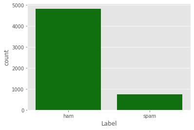

```python
plt.style.use('ggplot')
sns_plot = sns.countplot(df['Label'], data=df, color="g")
sns_plot.get_figure().savefig('Spam-Ham-Distribution.png')
```

```python
print(df['Label'].value_counts()) #ham count is 2 less as compared to given in paper
print(len(df))
```

```
ham     4825
spam     747
Name: Label, dtype: int64
5572
```

```python
rep_dict = {
                  "Label":
                        {
                          "ham": 0,
                          "spam":1
                         }
            }
df.replace(rep_dict, inplace=True)
df.head()
```

|  | Label | Text |
| --- | --- | --- |
| 0 | 0 | Go until jurong point, crazy.. Available only ... |
| 1 | 0 | Ok lar... Joking wif u oni... |
| 2 | 1 | Free entry in 2 a wkly comp to win FA Cup fina... |
| 3 | 0 | U dun say so early hor... U c already then say... |
| 4 | 0 | Nah I don't think he goes to usf, he lives aro... |

```python
text = df['Text']
label = df['Label']
```

```python
label = to_categorical(label)
```

```python
label
```

```
array([[1., 0.],
       [1., 0.],
       [0., 1.],
       ...,
       [1., 0.],
       [1., 0.],
       [1., 0.]], dtype=float32)
```

```python
text
```

```
0       Go until jurong point, crazy.. Available only ...
1                           Ok lar... Joking wif u oni...
2       Free entry in 2 a wkly comp to win FA Cup fina...
3       U dun say so early hor... U c already then say...
4       Nah I don't think he goes to usf, he lives aro...
                              ...
5567    This is the 2nd time we have tried 2 contact u...
5568                 Will ü b going to esplanade fr home?
5569    Pity, * was in mood for that. So...any other s...
5570    The guy did some bitching but I acted like i'd...
5571                           Rofl. Its true to its name
Name: Text, Length: 5572, dtype: object
```

```python
print(text.shape)
print(label.shape)
```

```
(5572,)
(5572, 2)
```

```python
tokenize = Tokenizer()
tokenize.fit_on_texts(text)
text_seq = tokenize.texts_to_sequences(text)
```

```python
f = lambda sen : len(sen.split(' '))
len_of_sent = text.apply(f).to_list()
```

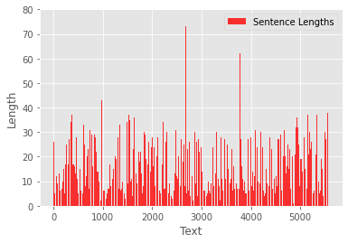

```python
plt.ylim(0, 80)
plt.bar(np.arange(0,len(len_of_sent),1),len_of_sent,align='center',alpha=0.8,color='red')
plt.legend(['Sentence Lengths'])
plt.xlabel('Text')
plt.ylabel('Length')
plt.show()
plt.savefig('Senetence_Length_distribution.png')
```

```python
n_timesteps = 32
x_pad = pad_sequences(text_seq,padding='post',maxlen = n_timesteps)
```

```python
x_pad
```

```
array([[  49,  471, 4436, ...,    0,    0,    0],
       [  46,  336, 1499, ...,    0,    0,    0],
       [  47,  489,    8, ...,  392, 2998,    0],
       ...,
       [9007,   60,    8, ...,    0,    0,    0],
       [   5,  534,  114, ...,    0,    0,    0],
       [2687,   61,  465, ...,    0,    0,    0]], dtype=int32)
```

```python
embeddings_vector = {}
with open('glove.twitter.27B.25d.txt', encoding="utf8") as f:
  for line in f:
      row = line.split()
      embeddings_vector[row[0]] = np.asarray(row[1:], dtype='float32')
print('Loaded Glove Vectors')
```

```
Loaded Glove Vectors
```

```python
embedding_dim = 25
embedding_matrix = np.random.random((len(tokenize.word_index) + 1, embedding_dim))
for w,i in tokenize.word_index.items():
  if w in embeddings_vector:
    embedding_matrix[i] = embeddings_vector[w]
```

```python
X_train, X_test, Y_train, Y_test = train_test_split(x_pad, label, test_size=0.30, random_state=42)
```

```python
print(X_train.shape,X_test.shape)
print(Y_train.shape,Y_test.shape)
```

```
(3900, 32) (1672, 32)
(3900, 2) (1672, 2)
```

# **CNN Based Classifier**

```python
from tensorflow.keras.layers import Input,Dense,MaxPooling1D, Dropout, Activation, Flatten, Embedding, Conv1D, MaxPool1D
from tensorflow.keras.utils import plot_model
from tensorflow.keras.models import Model
from keras import backend as K
K.clear_session()
```

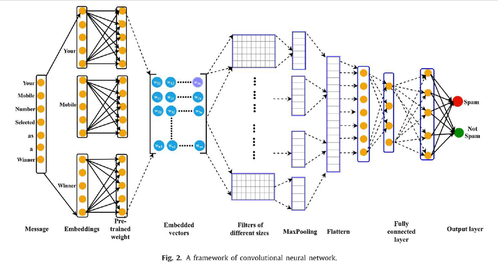

```python
from IPython.display import Image, display
display(Image('/content/drive/My Drive/ML-Assignment/Architecture.PNG'))
```

```python
def create_model(model_name='CNN_Spam_Classifier'):
  inp_layer = Input(shape=(n_timesteps,),name='Message')
  vocab_size = len(tokenize.word_index) +  1
  emb_layer = Embedding(input_dim = vocab_size,output_dim=embedding_dim,weights=[embedding_matrix],input_length=n_timesteps,trainable=False,name='Embedding')(inp_layer)
  conv_layer_1 = Conv1D(filters=128,kernel_size=2,activation='relu',name='Convolution_Layer_1')(emb_layer)
  pool_layer_1 = MaxPooling1D(5,name='Pooling_Layer_1')(conv_layer_1)
  flat1 = Flatten(name='Flattenned_Layer_1')(pool_layer_1)
  conv_layer_2 = Conv1D(filters=128,kernel_size=3,activation='relu',name='Convolution_Layer_2')(emb_layer)
  pool_layer_2 = MaxPooling1D(5,name='Pooling_Layer_2')(conv_layer_2)
  flat2 = Flatten(name='Flattenned_Layer_2')(pool_layer_2)
  conv_layer_3 = Conv1D(filters=128,kernel_size=4,activation='relu',name='Convolution_Layer_3')(emb_layer)
  pool_layer_3 = MaxPooling1D(5,name='Pooling_Layer_3')(conv_layer_3)
  flat3 = Flatten(name='Flattenned_Layer_3')(pool_layer_3)
  conv_layer_4 = Conv1D(filters=128,kernel_size=5,activation='relu',name='Convolution_Layer_4')(emb_layer)
  pool_layer_4 = MaxPooling1D(5,name='Pooling_Layer_4')(conv_layer_4)
  flat4 = Flatten(name='Flattenned_Layer_4')(pool_layer_4)
  flat = tensorflow.concat([flat1,flat2,flat3,flat4],axis=1,name='Concatenate_Flatten_Layers')
  dense_layer = Dense(256,activation='relu',name='Dense_Layer')(flat)
  dropout_layer = Dropout(0.3,name='Dropout_Layer')(dense_layer)
  output_layer = Dense(2,activation='softmax',name='Output_Layer')(dropout_layer)
  model = Model(inp_layer, output_layer,name=model_name)
  model.compile(loss='binary_crossentropy', optimizer='Adam', metrics=['accuracy'])
  return model
```

```
Model: "CNN_Spam_Classifier"
__________________________________________________________________________________________________
Layer (type)                    Output Shape         Param #     Connected to
==================================================================================================
Message (InputLayer)            [(None, 32)]         0
__________________________________________________________________________________________________
Embedding (Embedding)           (None, 32, 25)       225250      Message[0][0]
__________________________________________________________________________________________________
Convolution_Layer_1 (Conv1D)    (None, 31, 128)      6528        Embedding[0][0]
__________________________________________________________________________________________________
Convolution_Layer_2 (Conv1D)    (None, 30, 128)      9728        Embedding[0][0]
__________________________________________________________________________________________________
Convolution_Layer_3 (Conv1D)    (None, 29, 128)      12928       Embedding[0][0]
__________________________________________________________________________________________________
Convolution_Layer_4 (Conv1D)    (None, 28, 128)      16128       Embedding[0][0]
__________________________________________________________________________________________________
Pooling_Layer_1 (MaxPooling1D)  (None, 6, 128)       0           Convolution_Layer_1[0][0]
__________________________________________________________________________________________________
Pooling_Layer_2 (MaxPooling1D)  (None, 6, 128)       0           Convolution_Layer_2[0][0]
__________________________________________________________________________________________________
Pooling_Layer_3 (MaxPooling1D)  (None, 5, 128)       0           Convolution_Layer_3[0][0]
__________________________________________________________________________________________________
Pooling_Layer_4 (MaxPooling1D)  (None, 5, 128)       0           Convolution_Layer_4[0][0]
__________________________________________________________________________________________________
Flattenned_Layer_1 (Flatten)    (None, 768)          0           Pooling_Layer_1[0][0]
__________________________________________________________________________________________________
Flattenned_Layer_2 (Flatten)    (None, 768)          0           Pooling_Layer_2[0][0]
__________________________________________________________________________________________________
Flattenned_Layer_3 (Flatten)    (None, 640)          0           Pooling_Layer_3[0][0]
__________________________________________________________________________________________________
Flattenned_Layer_4 (Flatten)    (None, 640)          0           Pooling_Layer_4[0][0]
__________________________________________________________________________________________________
tf_op_layer_Concatenate_Flatten [(None, 2816)]       0           Flattenned_Layer_1[0][0]
                                                                 Flattenned_Layer_2[0][0]
                                                                 Flattenned_Layer_3[0][0]
                                                                 Flattenned_Layer_4[0][0]
__________________________________________________________________________________________________
Dense_Layer (Dense)             (None, 256)          721152      tf_op_layer_Concatenate_Flatten_L
__________________________________________________________________________________________________
Dropout_Layer (Dropout)         (None, 256)          0           Dense_Layer[0][0]
__________________________________________________________________________________________________
Output_Layer (Dense)            (None, 2)            514         Dropout_Layer[0][0]
==================================================================================================
Total params: 992,228
Trainable params: 766,978
Non-trainable params: 225,250
__________________________________________________________________________________________________
```

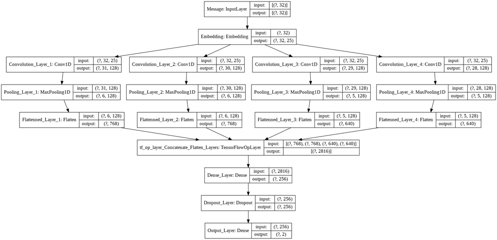

```python
model = create_model()
model.summary()
plot_model(model, to_file='cnn_model.png', show_shapes=True, show_layer_names=True)
```

```python
from tensorflow.keras.callbacks import ModelCheckpoint,EarlyStopping
es = EarlyStopping(monitor='val_accuracy', mode='max', patience=5,verbose=1)
filepath = r"/content/drive/My Drive/ML-Assignment/Classifier.h5"
checkpoint = ModelCheckpoint(filepath=filepath, save_weights_only=False,monitor='val_accuracy',mode='max',save_best_only=True)
callbacks_list = [checkpoint,es]
```

```python
history = model.fit(X_train, Y_train, validation_data = (X_test, Y_test),callbacks=callbacks_list, epochs=50,batch_size=100, verbose=2)
```

```
39/39 - 3s - loss: 2.0486 - accuracy: 0.8523 - val_loss: 2.0547 - val_accuracy: 0.8660
39/39 - 2s - loss: 2.0567 - accuracy: 0.8659 - val_loss: 2.0547 - val_accuracy: 0.8660
39/39 - 2s - loss: 2.0555 - accuracy: 0.8659 - val_loss: 2.0547 - val_accuracy: 0.8660
39/39 - 2s - loss: 1.8684 - accuracy: 0.8513 - val_loss: 0.5603 - val_accuracy: 0.8660
39/39 - 2s - loss: 0.1994 - accuracy: 0.9385 - val_loss: 0.0854 - val_accuracy: 0.9689
39/39 - 2s - loss: 0.0757 - accuracy: 0.9738 - val_loss: 0.0677 - val_accuracy: 0.9779
39/39 - 2s - loss: 0.0488 - accuracy: 0.9841 - val_loss: 0.0628 - val_accuracy: 0.9785
39/39 - 2s - loss: 0.0383 - accuracy: 0.9879 - val_loss: 0.0581 - val_accuracy: 0.9809
39/39 - 2s - loss: 0.0235 - accuracy: 0.9926 - val_loss: 0.0617 - val_accuracy: 0.9844
39/39 - 1s - loss: 0.0153 - accuracy: 0.9954 - val_loss: 0.0640 - val_accuracy: 0.9844
39/39 - 2s - loss: 0.0099 - accuracy: 0.9979 - val_loss: 0.0616 - val_accuracy: 0.9833
39/39 - 2s - loss: 0.0068 - accuracy: 0.9992 - val_loss: 0.0659 - val_accuracy: 0.9839
39/39 - 2s - loss: 0.0039 - accuracy: 0.9995 - val_loss: 0.0681 - val_accuracy: 0.9803
39/39 - 2s - loss: 0.0035 - accuracy: 0.9995 - val_loss: 0.0689 - val_accuracy: 0.9839
Epoch 00014: early stopping
```

```python
history.history.keys()
```

```
dict_keys(['loss', 'accuracy', 'val_loss', 'val_accuracy'])
```

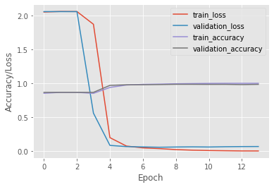

```python
from matplotlib import pyplot as plt
plt.plot(history.history['loss'], label='train_loss')
plt.plot(history.history['val_loss'], label='validation_loss')
plt.plot(history.history['accuracy'], label='train_accuracy')
plt.plot(history.history['val_accuracy'], label='validation_accuracy')
plt.xlabel('Epoch')
plt.ylabel('Accuracy/Loss')
plt.legend()
plt.show()
```

```python
out = model.predict(X_test)
```

```python
Y_pred = np.zeros_like(out)
Y_pred[np.arange(len(Y_pred)), out.argmax(axis = 1)] = 1
```

```python
from sklearn.metrics import accuracy_score
print(accuracy_score(Y_test,Y_pred))
```

```
0.9838516746411483
```

```python
def plot_confusion_matrix(cm,
                          target_names,
                          title='Confusion matrix',
                          cmap=None,
                          normalize=True):
    """
    given a sklearn confusion matrix (cm), make a nice plot

    Arguments
    ---------
    cm:           confusion matrix from sklearn.metrics.confusion_matrix

    target_names: given classification classes such as [0, 1, 2]
                  the class names, for example: ['high', 'medium', 'low']

    title:        the text to display at the top of the matrix

    cmap:         the gradient of the values displayed from matplotlib.pyplot.cm
                  see http://matplotlib.org/examples/color/colormaps_reference.html
                  plt.get_cmap('jet') or plt.cm.Blues

    normalize:    If False, plot the raw numbers
                  If True, plot the proportions

    Usage
    -----
    plot_confusion_matrix(cm           = cm,                  # confusion matrix created by
                                                              # sklearn.metrics.confusion_matrix
                          normalize    = True,                # show proportions
                          target_names = y_labels_vals,       # list of names of the classes
                          title        = best_estimator_name) # title of graph

    Citiation
    ---------
    http://scikit-learn.org/stable/auto_examples/model_selection/plot_confusion_matrix.html

    """
    import matplotlib.pyplot as plt
    import numpy as np
    import itertools

    accuracy = np.trace(cm) / float(np.sum(cm))
    misclass = 1 - accuracy

    if cmap is None:
        cmap = plt.get_cmap('Blues')

    plt.figure(figsize=(8, 6))
    plt.imshow(cm, interpolation='nearest', cmap=cmap)
    plt.title(title)
    plt.colorbar()

    if target_names is not None:
        tick_marks = np.arange(len(target_names))
        plt.xticks(tick_marks, target_names, rotation=45)
        plt.yticks(tick_marks, target_names)

    if normalize:
        cm = cm.astype('float') / cm.sum(axis=1)[:, np.newaxis]


    thresh = cm.max() / 1.5 if normalize else cm.max() / 2
    for i, j in itertools.product(range(cm.shape[0]), range(cm.shape[1])):
        if normalize:
            plt.text(j, i, "{:0.4f}".format(cm[i, j]),
                     horizontalalignment="center",
                     color="white" if cm[i, j] > thresh else "black")
        else:
            plt.text(j, i, "{:,}".format(cm[i, j]),
                     horizontalalignment="center",
                     color="white" if cm[i, j] > thresh else "black")


    plt.tight_layout()
    plt.ylabel('True label')
    plt.xlabel('Predicted label\naccuracy={:0.4f}; misclass={:0.4f}'.format(accuracy, misclass))
    plt.show()
```

```python
from sklearn.metrics import classification_report,confusion_matrix,roc_curve,auc,accuracy_score,roc_auc_score
cm = confusion_matrix(Y_test.argmax(axis=1), Y_pred.argmax(axis=1))
print(classification_report(Y_test,Y_pred,target_names=['ham','spam']))
aucs = roc_auc_score(Y_test, Y_pred)
print(f'ROC AUC: {aucs}')
```

```
              precision    recall  f1-score   support

         ham       0.99      0.99      0.99      1448
        spam       0.95      0.93      0.94       224

   micro avg       0.98      0.98      0.98      1672
   macro avg       0.97      0.96      0.97      1672
weighted avg       0.98      0.98      0.98      1672
 samples avg       0.98      0.98      0.98      1672

ROC AUC: 0.9623742107340174
```

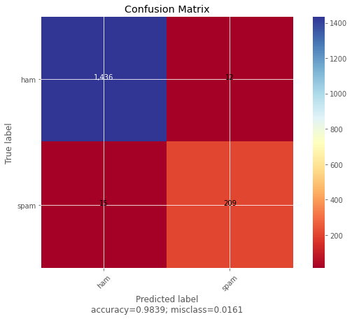

```python
plot_confusion_matrix(cm=cm,target_names=['ham','spam'],normalize=False,title='Confusion Matrix',cmap='RdYlBu')
```

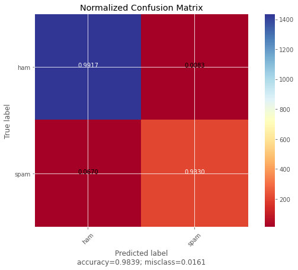

```python
plot_confusion_matrix(cm=cm,target_names=['ham','spam'],normalize=True,title='Normalized Confusion Matrix',cmap='RdYlBu')
```

```python
fpr = dict()
tpr = dict()
roc_auc = dict()
n_classes=2
lw = 2
for i in range(n_classes):
    fpr[i], tpr[i], _ = roc_curve(Y_test[:, i], Y_pred[:, i])
    roc_auc[i] = auc(fpr[i], tpr[i])

# Compute micro-average ROC curve and ROC area
fpr["micro"], tpr["micro"], _ = roc_curve(Y_test.ravel(), Y_pred.ravel())
roc_auc["micro"] = auc(fpr["micro"], tpr["micro"])
```

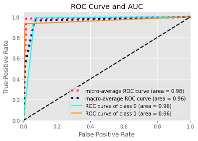

```python
from scipy import interp
from itertools import cycle
all_fpr = np.unique(np.concatenate([fpr[i] for i in range(n_classes)]))

# Then interpolate all ROC curves at this points
mean_tpr = np.zeros_like(all_fpr)
for i in range(n_classes):
    mean_tpr += interp(all_fpr, fpr[i], tpr[i])

# Finally average it and compute AUC
mean_tpr /= n_classes

fpr["macro"] = all_fpr
tpr["macro"] = mean_tpr
roc_auc["macro"] = auc(fpr["macro"], tpr["macro"])

# Plot all ROC curves
plt.figure()
plt.plot(fpr["micro"], tpr["micro"],
         label='micro-average ROC curve (area = {0:0.2f})'
               ''.format(roc_auc["micro"]),
         color='deeppink', linestyle=':', linewidth=4)

plt.plot(fpr["macro"], tpr["macro"],
         label='macro-average ROC curve (area = {0:0.2f})'
               ''.format(roc_auc["macro"]),
         color='navy', linestyle=':', linewidth=4)

colors = cycle(['aqua', 'darkorange', 'cornflowerblue'])
for i, color in zip(range(n_classes), colors):
    plt.plot(fpr[i], tpr[i], color=color, lw=lw,
             label='ROC curve of class {0} (area = {1:0.2f})'
             ''.format(i, roc_auc[i]))

plt.plot([0, 1], [0, 1], 'k--', lw=lw)
plt.xlim([0.0, 1.0])
plt.ylim([0.0, 1.05])
plt.xlabel('False Positive Rate')
plt.ylabel('True Positive Rate')
plt.title('ROC Curve and AUC')
plt.legend(loc="lower right")
plt.show()
```

## **Using 10-Fold CV**

```python
from sklearn.model_selection import KFold
n_split=10
X = x_pad
Y = label
cvscores = []
for train_index,test_index in KFold(n_split).split(X):
  x_train,x_test=X[train_index],X[test_index]
  y_train,y_test=Y[train_index],Y[test_index]
  model = create_model('K_Fold_Classifier')
  model.fit(x_train, y_train,epochs=10)
  scores = model.evaluate(x_test,y_test)
  print("%s: %.2f%%" % (model.metrics_names[1], scores[1]*100))
  cvscores.append(scores[1] * 100)
```

```
accuracy: 98.92%
accuracy: 98.57%
accuracy: 98.38%
accuracy: 98.56%
accuracy: 97.49%
accuracy: 98.74%
accuracy: 86.89%
accuracy: 98.20%
accuracy: 98.74%
accuracy: 98.74%
```

```python
print("Model Accuracy for 10 fold cross validation : %.2f%% (+/- %.2f%%)" % (np.mean(cvscores), np.std(cvscores)))
```

```
Model Accuracy for 10 fold cross validation : 97.33% (+/- 3.50%)
```

# **Simple LSTM Based Classifier**

```
Model: "model_name"
_________________________________________________________________
Layer (type)                 Output Shape              Param #
=================================================================
Message (InputLayer)         [(None, 32)]              0
_________________________________________________________________
Embedding (Embedding)        (None, 32, 25)            225250
_________________________________________________________________
LSTM_Layer_1 (LSTM)          (None, 32, 256)           288768
_________________________________________________________________
LSTM_Layer_2 (LSTM)          (None, 128)               197120
_________________________________________________________________
Dense_Layer (Dense)          (None, 256)               33024
_________________________________________________________________
Dropout_Layer (Dropout)      (None, 256)               0
_________________________________________________________________
Output_Layer (Dense)         (None, 2)                 514
=================================================================
Total params: 744,676
Trainable params: 519,426
Non-trainable params: 225,250
_________________________________________________________________
```

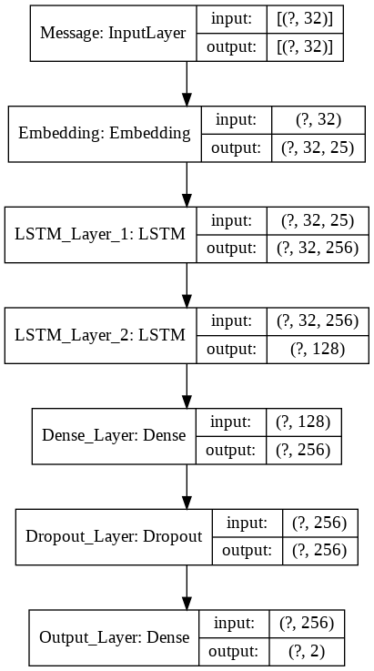

```python
from tensorflow.keras.layers import LSTM, Bidirectional
def create_lstm_model(model_name='Simple_LSTM_Classifier'):
  latent_dim = 256
  inp_layer = Input(shape=(n_timesteps,),name='Message')
  vocab_size = len(tokenize.word_index) +  1
  emb_layer = Embedding(input_dim = vocab_size,output_dim=embedding_dim,weights=[embedding_matrix],input_length=n_timesteps,trainable=False,name='Embedding')(inp_layer)
  LSTM_1=LSTM(units = latent_dim,return_sequences=True,name='LSTM_Layer_1',dropout=0.3,recurrent_dropout=0.2)(emb_layer)
  output=LSTM(units = latent_dim//2,return_sequences=False,name='LSTM_Layer_2',dropout=0.3,recurrent_dropout=0.2)(LSTM_1)
  dense_layer = Dense(256,activation='relu',name='Dense_Layer')(output)
  dropout_layer = Dropout(0.3,name='Dropout_Layer')(dense_layer)
  output_layer = Dense(2,activation='softmax',name='Output_Layer')(dropout_layer)
  model = Model(inp_layer, output_layer,name='model_name')
  model.compile(loss='binary_crossentropy', optimizer='Adam', metrics=['accuracy'])
  return model
model = create_lstm_model()
model.summary()
plot_model(model, to_file='LSTM_model.png', show_shapes=True, show_layer_names=True)
```

```python
from tensorflow.keras.callbacks import ModelCheckpoint,EarlyStopping
es = EarlyStopping(monitor='val_accuracy', mode='max', patience=5,verbose=1)
filepath = r"/content/drive/My Drive/ML-Assignment/LSTM_Classifier.h5"
checkpoint = ModelCheckpoint(filepath=filepath, save_weights_only=False,monitor='val_accuracy',mode='max',save_best_only=True)
callbacks_list = [checkpoint,es]
```

```python
history = model.fit(X_train, Y_train, validation_data = (X_test, Y_test),callbacks=callbacks_list, epochs=20,batch_size=100, verbose=2)
```

```
39/39 - 24s - loss: 0.2427 - accuracy: 0.9015 - val_loss: 0.1149 - val_accuracy: 0.9629
39/39 - 23s - loss: 0.1348 - accuracy: 0.9538 - val_loss: 0.1040 - val_accuracy: 0.9653
39/39 - 22s - loss: 0.1186 - accuracy: 0.9600 - val_loss: 0.0995 - val_accuracy: 0.9653
39/39 - 23s - loss: 0.1062 - accuracy: 0.9626 - val_loss: 0.0866 - val_accuracy: 0.9695
39/39 - 24s - loss: 0.1133 - accuracy: 0.9672 - val_loss: 0.1134 - val_accuracy: 0.9707
39/39 - 23s - loss: 0.0964 - accuracy: 0.9718 - val_loss: 0.0758 - val_accuracy: 0.9785
39/39 - 23s - loss: 0.0937 - accuracy: 0.9700 - val_loss: 0.0680 - val_accuracy: 0.9803
39/39 - 22s - loss: 0.0831 - accuracy: 0.9715 - val_loss: 0.0821 - val_accuracy: 0.9737
39/39 - 22s - loss: 0.0908 - accuracy: 0.9687 - val_loss: 0.0637 - val_accuracy: 0.9785
39/39 - 22s - loss: 0.0721 - accuracy: 0.9767 - val_loss: 0.0773 - val_accuracy: 0.9773
39/39 - 22s - loss: 0.0707 - accuracy: 0.9754 - val_loss: 0.0643 - val_accuracy: 0.9767
39/39 - 23s - loss: 0.0799 - accuracy: 0.9759 - val_loss: 0.0598 - val_accuracy: 0.9827
39/39 - 22s - loss: 0.0692 - accuracy: 0.9787 - val_loss: 0.0600 - val_accuracy: 0.9827
39/39 - 22s - loss: 0.0604 - accuracy: 0.9800 - val_loss: 0.0518 - val_accuracy: 0.9827
39/39 - 22s - loss: 0.0704 - accuracy: 0.9767 - val_loss: 0.0605 - val_accuracy: 0.9791
39/39 - 22s - loss: 0.0571 - accuracy: 0.9833 - val_loss: 0.0580 - val_accuracy: 0.9779
39/39 - 22s - loss: 0.0565 - accuracy: 0.9818 - val_loss: 0.0539 - val_accuracy: 0.9827
Epoch 00017: early stopping
```

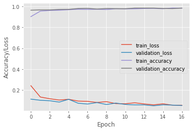

```python
from matplotlib import pyplot as plt
plt.plot(history.history['loss'], label='train_loss')
plt.plot(history.history['val_loss'], label='validation_loss')
plt.plot(history.history['accuracy'], label='train_accuracy')
plt.plot(history.history['val_accuracy'], label='validation_accuracy')
plt.xlabel('Epoch')
plt.ylabel('Accuracy/Loss')
plt.legend()
plt.show()
```

```python
out = model.predict(X_test)
Y_pred = np.zeros_like(out)
Y_pred[np.arange(len(Y_pred)), out.argmax(axis = 1)] = 1
print(accuracy_score(Y_test,Y_pred))
```

```
0.9826555023923444
```

```python
from sklearn.metrics import classification_report,confusion_matrix,roc_curve,auc,accuracy_score,roc_auc_score
cm = confusion_matrix(Y_test.argmax(axis=1), Y_pred.argmax(axis=1))
print(classification_report(Y_test,Y_pred,target_names=['ham','spam']))
aucs = roc_auc_score(Y_test, Y_pred)
print(f'ROC AUC: {aucs}')
```

```
              precision    recall  f1-score   support

         ham       0.99      0.99      0.99      1448
        spam       0.92      0.95      0.94       224

   micro avg       0.98      0.98      0.98      1672
   macro avg       0.96      0.97      0.96      1672
weighted avg       0.98      0.98      0.98      1672
 samples avg       0.98      0.98      0.98      1672

ROC AUC: 0.9692309589581689
```

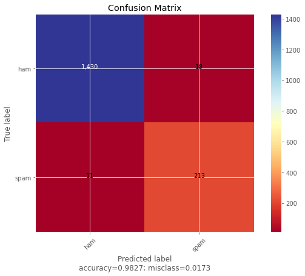

```python
plot_confusion_matrix(cm=cm,target_names=['ham','spam'],normalize=False,title='Confusion Matrix',cmap='RdYlBu')
```

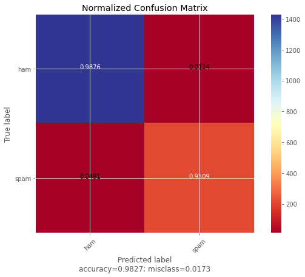

```python
plot_confusion_matrix(cm=cm,target_names=['ham','spam'],normalize=True,title='Normalized Confusion Matrix',cmap='RdYlBu')
```

```python
fpr = dict()
tpr = dict()
roc_auc = dict()
n_classes=2
for i in range(n_classes):
    fpr[i], tpr[i], _ = roc_curve(Y_test[:, i], Y_pred[:, i])
    roc_auc[i] = auc(fpr[i], tpr[i])

# Compute micro-average ROC curve and ROC area
fpr["micro"], tpr["micro"], _ = roc_curve(Y_test.ravel(), Y_pred.ravel())
roc_auc["micro"] = auc(fpr["micro"], tpr["micro"])
```

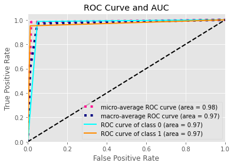

```python
from scipy import interp
from itertools import cycle
all_fpr = np.unique(np.concatenate([fpr[i] for i in range(n_classes)]))

# Then interpolate all ROC curves at this points
mean_tpr = np.zeros_like(all_fpr)
for i in range(n_classes):
    mean_tpr += interp(all_fpr, fpr[i], tpr[i])

# Finally average it and compute AUC
mean_tpr /= n_classes

fpr["macro"] = all_fpr
tpr["macro"] = mean_tpr
roc_auc["macro"] = auc(fpr["macro"], tpr["macro"])

# Plot all ROC curves
plt.figure()
plt.plot(fpr["micro"], tpr["micro"],
         label='micro-average ROC curve (area = {0:0.2f})'
               ''.format(roc_auc["micro"]),
         color='deeppink', linestyle=':', linewidth=4)

plt.plot(fpr["macro"], tpr["macro"],
         label='macro-average ROC curve (area = {0:0.2f})'
               ''.format(roc_auc["macro"]),
         color='navy', linestyle=':', linewidth=4)

colors = cycle(['aqua', 'darkorange', 'cornflowerblue'])
for i, color in zip(range(n_classes), colors):
    plt.plot(fpr[i], tpr[i], color=color, lw=lw,
             label='ROC curve of class {0} (area = {1:0.2f})'
             ''.format(i, roc_auc[i]))

plt.plot([0, 1], [0, 1], 'k--', lw=lw)
plt.xlim([0.0, 1.0])
plt.ylim([0.0, 1.05])
plt.xlabel('False Positive Rate')
plt.ylabel('True Positive Rate')
plt.title('ROC Curve and AUC')
plt.legend(loc="lower right")
plt.show()
```

# **Attention Based BiLSTM Model**

```python
from tensorflow.keras.layers import Input,Dense,Dropout, Activation, Flatten, Embedding,Bidirectional,LSTM
from tensorflow.keras.utils import plot_model
from tensorflow.keras.models import Model
```

```python
class attention(Layer):
    def __init__(self,**kwargs):
        super(attention,self).__init__(**kwargs)

    def build(self,input_shape):
        self.W=self.add_weight(name="att_weight",shape=(input_shape[-1],1),initializer="normal")
        self.b=self.add_weight(name="att_bias",shape=(input_shape[1],1),initializer="zeros")
        super(attention, self).build(input_shape)

    def call(self,x):
        et=K.squeeze(K.tanh(K.dot(x,self.W)+self.b),axis=-1)
        at=K.softmax(et)
        at=K.expand_dims(at,axis=-1)
        output=x*at
        return K.sum(output,axis=1)

    def compute_output_shape(self,input_shape):
        return (input_shape[0],input_shape[-1])

    def get_config(self):
        return super(attention,self).get_config()
```

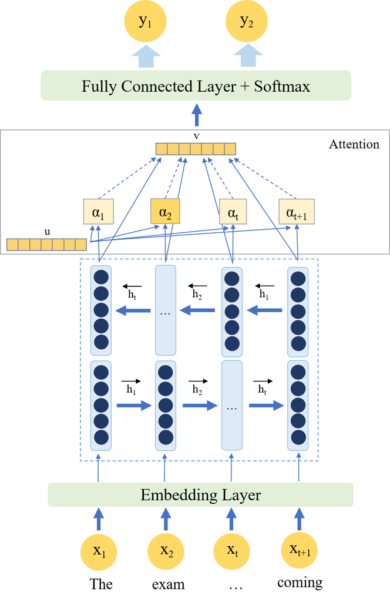

```python
display(Image('/content/drive/My Drive/ML-Assignment/Attention_BiLSTM.png'))
```

```
Model: "Attention_BiLSTM_Classifier"
_________________________________________________________________
Layer (type)                 Output Shape              Param #
=================================================================
Message (InputLayer)         [(None, 32)]              0
_________________________________________________________________
Embedding (Embedding)        (None, 32, 25)            225250
_________________________________________________________________
bidirectional_2 (Bidirection (None, 32, 512)           577536
_________________________________________________________________
bidirectional_3 (Bidirection (None, 32, 256)           656384
_________________________________________________________________
attention_1 (attention)      (None, 256)               288
_________________________________________________________________
Output_Layer (Dense)         (None, 2)                 514
=================================================================
Total params: 1,459,972
Trainable params: 1,234,722
Non-trainable params: 225,250
_________________________________________________________________
```

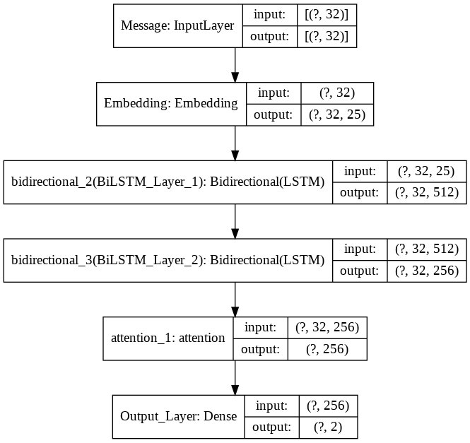

```python
def create_attention_lstm_model(model_name='Attention_BiLSTM_Classifier'):
  latent_dim = 256
  inp_layer = Input(shape=(n_timesteps,),name='Message')
  vocab_size = len(tokenize.word_index) +  1
  emb_layer = Embedding(input_dim = vocab_size,output_dim=embedding_dim,weights=[embedding_matrix],input_length=n_timesteps,trainable=False,name='Embedding')(inp_layer)
  BiLSTM_1=Bidirectional(LSTM(units = latent_dim,return_sequences=True,name='BiLSTM_Layer_1',dropout=0.3,recurrent_dropout=0.2))(emb_layer)
  att_in=Bidirectional(LSTM(units = latent_dim//2,return_sequences=True,name='BiLSTM_Layer_2',dropout=0.3,recurrent_dropout=0.2))(BiLSTM_1)
  att_out = attention()(att_in)
  # dense_layer = Dense(128,activation='relu',name='Dense_Layer')(att_out)
  # dropout_layer = Dropout(0.3,name='Dropout_Layer')(dense_layer)
  output_layer = Dense(2,activation='softmax',name='Output_Layer')(att_out)
  model = Model(inp_layer,output_layer,name=model_name)
  model.compile(loss='binary_crossentropy', optimizer='Adam', metrics=['accuracy'])
  return model
model = create_attention_lstm_model()
model.summary()
plot_model(model, to_file='Attention_BiLSTM_model.png', show_shapes=True, show_layer_names=True)
```

```python
from tensorflow.keras.callbacks import ModelCheckpoint,EarlyStopping
es = EarlyStopping(monitor='val_loss', mode='min', patience=5,verbose=1)
filepath = r"/content/drive/My Drive/ML-Assignment/Attention_BiLSTM_Classifier.h5"
checkpoint = ModelCheckpoint(filepath=filepath, save_weights_only=False,monitor='val_accuracy',mode='max',save_best_only=True)
callbacks_list = [checkpoint,es]
```

```python
history = model.fit(X_train, Y_train, validation_data = (X_test, Y_test),callbacks=callbacks_list, epochs=20,batch_size=100, verbose=2)
```

```
39/39 - 53s - loss: 0.2131 - accuracy: 0.9151 - val_loss: 0.1081 - val_accuracy: 0.9641
39/39 - 54s - loss: 0.1110 - accuracy: 0.9618 - val_loss: 0.0818 - val_accuracy: 0.9719
39/39 - 54s - loss: 0.1029 - accuracy: 0.9669 - val_loss: 0.0725 - val_accuracy: 0.9743
39/39 - 52s - loss: 0.0942 - accuracy: 0.9695 - val_loss: 0.0976 - val_accuracy: 0.9611
39/39 - 54s - loss: 0.0984 - accuracy: 0.9656 - val_loss: 0.0614 - val_accuracy: 0.9815
39/39 - 52s - loss: 0.0858 - accuracy: 0.9713 - val_loss: 0.0648 - val_accuracy: 0.9785
39/39 - 54s - loss: 0.0736 - accuracy: 0.9731 - val_loss: 0.0554 - val_accuracy: 0.9868
39/39 - 52s - loss: 0.0739 - accuracy: 0.9754 - val_loss: 0.0602 - val_accuracy: 0.9803
39/39 - 53s - loss: 0.0675 - accuracy: 0.9764 - val_loss: 0.0544 - val_accuracy: 0.9815
39/39 - 53s - loss: 0.0696 - accuracy: 0.9777 - val_loss: 0.0731 - val_accuracy: 0.9749
39/39 - 54s - loss: 0.0613 - accuracy: 0.9808 - val_loss: 0.0437 - val_accuracy: 0.9874
39/39 - 54s - loss: 0.0607 - accuracy: 0.9795 - val_loss: 0.0457 - val_accuracy: 0.9892
39/39 - 52s - loss: 0.0545 - accuracy: 0.9841 - val_loss: 0.0502 - val_accuracy: 0.9856
39/39 - 52s - loss: 0.0484 - accuracy: 0.9838 - val_loss: 0.0598 - val_accuracy: 0.9797
39/39 - 52s - loss: 0.0533 - accuracy: 0.9826 - val_loss: 0.0748 - val_accuracy: 0.9719
39/39 - 52s - loss: 0.0592 - accuracy: 0.9800 - val_loss: 0.0487 - val_accuracy: 0.9868
Epoch 00016: early stopping
```

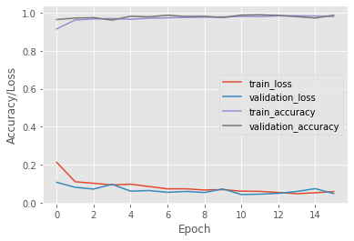

```python
from matplotlib import pyplot as plt
plt.plot(history.history['loss'], label='train_loss')
plt.plot(history.history['val_loss'], label='validation_loss')
plt.plot(history.history['accuracy'], label='train_accuracy')
plt.plot(history.history['val_accuracy'], label='validation_accuracy')
plt.xlabel('Epoch')
plt.ylabel('Accuracy/Loss')
plt.title('Training Curve')
plt.legend()
plt.show()
```

```python
out = model.predict(X_test)
Y_pred = np.zeros_like(out)
Y_pred[np.arange(len(Y_pred)), out.argmax(axis = 1)] = 1
print(accuracy_score(Y_test,Y_pred))
```

```
0.9868421052631579
```

```python
from sklearn.metrics import classification_report,confusion_matrix,roc_curve,auc,accuracy_score,roc_auc_score
cm = confusion_matrix(Y_test.argmax(axis=1), Y_pred.argmax(axis=1))
print(classification_report(Y_test,Y_pred,target_names=['ham','spam']))
aucs = roc_auc_score(Y_test, Y_pred)
print(f'ROC AUC: {aucs}')
```

```
              precision    recall  f1-score   support

         ham       0.99      0.99      0.99      1448
        spam       0.94      0.96      0.95       224

   micro avg       0.99      0.99      0.99      1672
   macro avg       0.97      0.98      0.97      1672
weighted avg       0.99      0.99      0.99      1672
 samples avg       0.99      0.99      0.99      1672

ROC AUC: 0.9754217640094712
```

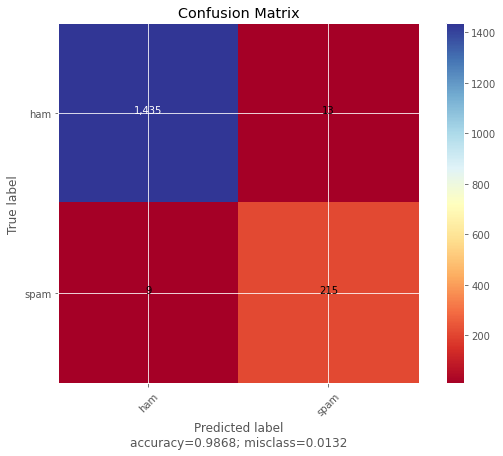

```python
plot_confusion_matrix(cm=cm,target_names=['ham','spam'],normalize=False,title='Confusion Matrix',cmap='RdYlBu')
```

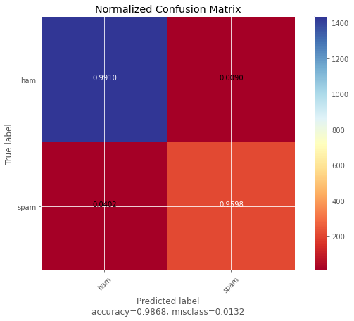

```python
plot_confusion_matrix(cm=cm,target_names=['ham','spam'],normalize=True,title='Normalized Confusion Matrix',cmap='RdYlBu')
```

```python
fpr = dict()
tpr = dict()
roc_auc = dict()
n_classes=2
for i in range(n_classes):
    fpr[i], tpr[i], _ = roc_curve(Y_test[:, i], Y_pred[:, i])
    roc_auc[i] = auc(fpr[i], tpr[i])

# Compute micro-average ROC curve and ROC area
fpr["micro"], tpr["micro"], _ = roc_curve(Y_test.ravel(), Y_pred.ravel())
roc_auc["micro"] = auc(fpr["micro"], tpr["micro"])
```

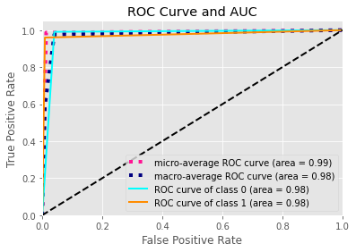

```python
from scipy import interp
from itertools import cycle
all_fpr = np.unique(np.concatenate([fpr[i] for i in range(n_classes)]))

# Then interpolate all ROC curves at this points
mean_tpr = np.zeros_like(all_fpr)
for i in range(n_classes):
    mean_tpr += interp(all_fpr, fpr[i], tpr[i])

# Finally average it and compute AUC
mean_tpr /= n_classes

fpr["macro"] = all_fpr
tpr["macro"] = mean_tpr
roc_auc["macro"] = auc(fpr["macro"], tpr["macro"])

# Plot all ROC curves
plt.figure()
plt.plot(fpr["micro"], tpr["micro"],
         label='micro-average ROC curve (area = {0:0.2f})'
               ''.format(roc_auc["micro"]),
         color='deeppink', linestyle=':', linewidth=4)

plt.plot(fpr["macro"], tpr["macro"],
         label='macro-average ROC curve (area = {0:0.2f})'
               ''.format(roc_auc["macro"]),
         color='navy', linestyle=':', linewidth=4)

colors = cycle(['aqua', 'darkorange', 'cornflowerblue'])
for i, color in zip(range(n_classes), colors):
    plt.plot(fpr[i], tpr[i], color=color, lw=lw,
             label='ROC curve of class {0} (area = {1:0.2f})'
             ''.format(i, roc_auc[i]))

plt.plot([0, 1], [0, 1], 'k--', lw=lw)
plt.xlim([0.0, 1.0])
plt.ylim([0.0, 1.05])
plt.xlabel('False Positive Rate')
plt.ylabel('True Positive Rate')
plt.title('ROC Curve and AUC')
plt.legend(loc="lower right")
plt.show()
```

# Result Analysis

- For the CNN Model, We managed to get close reported score and AUC value but can't reach completely with a AUC value of 96.23 instead of AUC score 96.8 and accuracy of 98.38% instead of 98.63% which is reported in paper.
- However out 10 fold Cross validation doesn't performed very well with an accuracy of 97.33% as compared to papers ground breaking 99.44%. Though I believe with increased no of epochs and some other minor tweakings we can get much close to the score if we have time.
- Also, We tried with both Glove's twitter text and wikipedia crawled text pretrained weights and found that twitter text pretrained weights are giving higher accuracy
- For the Simple LSTM model We got accuracy more than mentioned in paper with a value of 98.26% instead of 96.67% which is mentioned in paper
- Also we tried another Attention based implementation with BiLSTM network which is not mentioned in paper but found that It fetches better score than the Simple LSTM model with an accuracy of 98.68% and remarkable AUC value of 97.54 instead of what was with simple LSTM i.e. 98.26% accuracy and AUC of 96.92

# Insights and Views

- After seeing the effect of using Attention over Simple LSTM, we think If we use Self attention based contextual word embeddings like Elmo, BERT etc. instead of Glove word embeddings we may get a better score.

# References & Paper **Used**(Beside what mentioned in paper)

- [Attention? Attention](https://lilianweng.github.io/lil-log/2018/06/24/attention-attention.html)
- [Attention-based bidirectional LSTM for Classification Task (ICASSP)](https://github.com/gentaiscool/lstm-attention) [Paper](https://arxiv.org/pdf/1805.12307.pdf)
- [Glove Vectors](https://github.com/stanfordnlp/GloVe)
- [Bahdanau Attention AnalyticsVidhya](https://www.analyticsvidhya.com/blog/2019/11/comprehensive-guide-attention-mechanism-deep-learning/)